# LAB10

3/28/2019

## Outline

- Gaussian AME model: `ame`
- Different relation: `ame(...,model=,...)`
  - ordinal data
  - censored and fixed rank nomination data
  - sampled or missing data
- symmetric relation: `ame(...,symmetric=TRUE,...)`
- repeated measures data: longitudal data `ame_rep(Y,Xdyad,Xrow,Xcol)`

Tutorial: https://github.com/pdhoff/amen/blob/master/inst/doc/amen.pdf

## `ame`

\[z_{i,j}=\beta_d^Tx_{d,i,j}+\beta_r^Tx_{r,i}+\beta_c^Tx_{c,j}+\mu+a_i+b_j+u_i^Tv_j+\epsilon_{i,j}\]

\[y_{i,j}=g(z_{i,j})\]

`ame(Y,Xd,Xr,Xc,model,R,rvar=TRUE,cvar=TRUE,dcor=TRUE,symmetric=FALSE)`

model:

- “nrm”: continuous Y
- “bin”: binary Y
- “ord”: ordinal Y
- “cbin”: censored binary Y
- “frn”: fixed rank Y
- “rrl”: row ranks (relationships across rows of Y are not directly comparable)
- Y: named matrix \(n\times n \times p_d\)
- Xd: named array (dyadic covariates)
- Xr: named matrix (nodal covariates)
- Xc: named matrix (nodal covariates)
- R: number (dimension of latent factor)
- rvar,cvar,dcor: whether to include row/column/corr effect or not
- symmetric: symmetric outcome or not

## Input: prepare the dataset

## prepare the dataset

- Get the Xnode,Xdyad from `igraph` object.
- Get the Xnode,Xdyad from edgelist dataframe.

```r
library(igraph)
library(igraphdata)
library(dplyr)
```

From `igraph` object:

```r
data("USairports")
?USairports
USairports
```

```
## IGRAPH bf6202d DN-- 755 23473 -- US airports
## + attr: name (g/c), name (v/c), City (v/c), Position (v/c),
## | Carrier (e/c), Departures (e/n), Seats (e/n), Passengers (e/n),
## | Aircraft (e/n), Distance (e/n)
## + edges from bf6202d (vertex names):
##  [1] BGR->JFK BGR->JFK BOS->EWR ANC->JFK JFK->ANC LAS->LAX MIA->JFK
##  [8] EWR->ANC BJC->MIA MIA->BJC TEB->ANC JFK->LAX LAX->JFK LAX->SFO
## [15] AEX->LAS BFI->SBA ELM->PIT GEG->SUN ICT->PBI LAS->LAX LAS->PBI
## [22] LAS->SFO LAX->LAS PBI->AEX PBI->ICT PIT->VCT SFO->LAX VCT->DWH
## [29] IAD->JFK ABE->CLT ABE->HPN AGS->CLT AGS->CLT AVL->CLT AVL->CLT
## [36] AVP->CLT AVP->PHL BDL->CLT BHM->CLT BHM->CLT BNA->CLT BNA->CLT
## + ... omitted several edges
```

```r
#For vertex attributes -Xnode
Xnode_ls=vertex_attr(USairports)
Xnode=matrix(unlist(Xnode_ls),ncol=length(Xnode_ls))
colnames(Xnode)=names(Xnode_ls)
rownames(Xnode)=Xnode_ls$name
Xnode=Xnode[,-1]

#For edge attributes - Xdyad
Xdyad_ls=edge_attr(USairports)
Xdyad=array(c(as_adjacency_matrix(USairports,sparse = FALSE),unlist(Xdyad_ls)),dim=c(nrow(Xnode),nrow(Xnode),length(Xdyad_ls)+1))
dimnames(Xdyad)[[1]]=dimnames(Xdyad)[[2]]=Xnode_ls$name
dimnames(Xdyad)[[3]]=c("relation",names(Xdyad_ls))
```

From dataframe:

transfer it to a `igraph` then to the array may be the easiest.

```r
#Xdyad
df=igraph::as_data_frame(USairports)
net=graph_from_data_frame(df)

vnames=V(net)$name

Xdyad_ls=edge_attr(USairports)
Xdyad=array(c(as_adjacency_matrix(USairports,sparse = FALSE),unlist(Xdyad_ls)),dim=c(nrow(Xnode),nrow(Xnode),length(Xdyad_ls)+1))
dimnames(Xdyad)[[1]]=dimnames(Xdyad)[[2]]=vnames
dimnames(Xdyad)[[3]]=c("relation",names(Xdyad_ls))

#Xnode
#If your nodal attributes stored in a data.frame
Xnode_df=as.data.frame(Xnode)%>%mutate(Vertex=rownames(Xnode))%>%arrange(Vertex)
head(Xnode_df)
```

```
##                             City         Position Vertex
## 1              Peach Springs, AZ N355925 W1134859    1G4
## 2               Bradley Lake, AK N565311 W1340930    A23
## 3                 Pogo Mines, AK N592603 W1514228    A27
## 4                 Kiluda Bay, AK N570308 W1352046    A29
## 5 Allentown/Bethlehem/Easton, PA N403909 W0752625    ABE
## 6                    Abilene, TX N322441 W0994055    ABI
```

```r
#Xnode
#need to match the order of Xnode to the order of the Xdyad
Xnode_df=Xnode_df%>%arrange(match(Vertex,vnames))
Xnode=as.matrix(Xnode_df)
rownames(Xnode)=Xnode[,"Vertex"]
Xnode=Xnode[,-3]
Xnode%>%head()
```

```
##     City            Position
## BGR "Bangor, ME"    "N444827 W0684941"
## BOS "Boston, MA"    "N422152 W0710019"
## ANC "Anchorage, AK" "N611028 W1495947"
## JFK "New York, NY"  "N403823 W0734644"
## LAS "Las Vegas, NV" "N360449 W1150908"
## MIA "Miami, FL"     "N254736 W0801726"
```

## Fit the model: the Gaussian AME model (continuous Y)

## The Gaussian AME model

```r
#install.packages("amen")
library(amen)
library(ggplot2)
```

\(y_{i,j}=\mu+a_i+b_j+\epsilon_{i,j}\)

```r
# use the trade data (export) from top 30 countries ranked by gdp
data(IR90s)
names(IR90s) # list
```

```
## [1] "dyadvars" "nodevars"
```

```r
dim(IR90s$dyadvars) #- array
```

```
## [1] 130 130   5
```

```r
dimnames(IR90s$dyadvars)
```

```
## [[1]]
##   [1] "AFG" "ALB" "ALG" "ANG" "ARG" "AUL" "AUS" "BAH" "BEL" "BEN" "BFO"
##  [12] "BHU" "BNG" "BOL" "BOT" "BRA" "BUI" "BUL" "CAM" "CAN" "CAO" "CDI"
##  [23] "CEN" "CHA" "CHL" "CHN" "COL" "COM" "CON" "COS" "CUB" "CYP" "DEN"
##  [34] "DJI" "DOM" "DRC" "ECU" "EGY" "EQG" "FIN" "FJI" "FRN" "GAB" "GAM"
##  [45] "GHA" "GNB" "GRC" "GUA" "GUI" "GUY" "HAI" "HON" "HUN" "IND" "INS"
##  [56] "IRE" "IRN" "IRQ" "ISR" "ITA" "JAM" "JOR" "JPN" "KEN" "LAO" "LBR"
##  [67] "LES" "LIB" "MAA" "MAG" "MAL" "MAS" "MAW" "MEX" "MLI" "MON" "MOR"
##  [78] "MYA" "MZM" "NAM" "NEP" "NEW" "NIC" "NIG" "NIR" "NOR" "NTH" "OMA"
##  [89] "PAK" "PAN" "PAR" "PHI" "PNG" "POL" "POR" "PRK" "QAT" "ROK" "RUM"
## [100] "RWA" "SAF" "SAL" "SAU" "SEN" "SIE" "SIN" "SOM" "SPN" "SRI" "SUD"
## [111] "SWA" "SWD" "SWZ" "SYR" "TAW" "TAZ" "THI" "TOG" "TRI" "TUN" "TUR"
## [122] "UAE" "UGA" "UKG" "URU" "USA" "VEN" "YEM" "ZAM" "ZIM"
##
## [[2]]
##   [1] "AFG" "ALB" "ALG" "ANG" "ARG" "AUL" "AUS" "BAH" "BEL" "BEN" "BFO"
##  [12] "BHU" "BNG" "BOL" "BOT" "BRA" "BUI" "BUL" "CAM" "CAN" "CAO" "CDI"
##  [23] "CEN" "CHA" "CHL" "CHN" "COL" "COM" "CON" "COS" "CUB" "CYP" "DEN"
##  [34] "DJI" "DOM" "DRC" "ECU" "EGY" "EQG" "FIN" "FJI" "FRN" "GAB" "GAM"
##  [45] "GHA" "GNB" "GRC" "GUA" "GUI" "GUY" "HAI" "HON" "HUN" "IND" "INS"
##  [56] "IRE" "IRN" "IRQ" "ISR" "ITA" "JAM" "JOR" "JPN" "KEN" "LAO" "LBR"
##  [67] "LES" "LIB" "MAA" "MAG" "MAL" "MAS" "MAW" "MEX" "MLI" "MON" "MOR"
##  [78] "MYA" "MZM" "NAM" "NEP" "NEW" "NIC" "NIG" "NIR" "NOR" "NTH" "OMA"
##  [89] "PAK" "PAN" "PAR" "PHI" "PNG" "POL" "POR" "PRK" "QAT" "ROK" "RUM"
## [100] "RWA" "SAF" "SAL" "SAU" "SEN" "SIE" "SIN" "SOM" "SPN" "SRI" "SUD"
## [111] "SWA" "SWD" "SWZ" "SYR" "TAW" "TAZ" "THI" "TOG" "TRI" "TUN" "TUR"
## [122] "UAE" "UGA" "UKG" "URU" "USA" "VEN" "YEM" "ZAM" "ZIM"
##
## [[3]]
## [1] "conflicts"   "exports"     "distance"    "shared_igos" "polity_int"
```

```r
gdp=IR90s$nodevars[,2]
topgdp=which(gdp>=sort(gdp,decreasing = TRUE)[30])
Y=log(IR90s$dyadvars[topgdp,topgdp,2]+1)
Y[1:5,1:5]
```

```
##           ARG        AUL       BEL        BNG        BRA
## ARG        NA 0.05826891 0.2468601 0.03922071 1.76473080
## AUL 0.0861777         NA 0.3784364 0.10436002 0.21511138
## BEL 0.2700271 0.35065687        NA 0.01980263 0.39877612
## BNG 0.0000000 0.01980263 0.1222176         NA 0.01980263
## BRA 1.6937791 0.23901690 0.6205765 0.03922071         NA
```

## Social relations model (SRM)

\[y_{i,j}=\mu+a_i+b_j+\epsilon_{i,j}\]

Input: Y - a named matrix

```r
# fit the model
fit_SRM=ame(Y,model="nrm",plot=FALSE,print = FALSE) #normal AME model; by default: niter=10,000; save every 25; burnin=500
```

```r
#output
names(fit_SRM)
```

```
##  [1] "BETA" "VC"   "APM"  "BPM"  "U"    "V"    "UVPM" "EZ"   "YPM"  "GOF"
```

```r
mean(fit_SRM$BETA) #mu_hat
```

```
## [1] 0.6616995
```

```r
(muhat=mean(Y,na.rm = TRUE))
```

```
## [1] 0.680044
```

```r
apply(fit_SRM$VC,2,mean) # covariance
```

```
##        va       cab        vb       rho        ve
## 0.2809375 0.2364107 0.2722367 0.8577201 0.2387065
```

```r
ahat=rowMeans(Y,na.rm = TRUE)-mean(Y,na.rm = TRUE)
bhat=colMeans(Y,na.rm = TRUE)-mean(Y,na.rm = TRUE)
(corab=cov(cbind(ahat,bhat)))
```

```
##           ahat      bhat
## ahat 0.2407563 0.2290788
## bhat 0.2290788 0.2289489
```

```r
(R=Y-(muhat+outer(ahat,bhat,"+")))
```

```
##             ARG          AUL         BEL          BNG         BRA
## ARG          NA -0.138060630 -0.23544663  0.312875331  1.63527007
## AUL -0.16956545           NA -0.43273546  0.049149445 -0.24321454
## BEL -0.21364558 -0.402467428          NA -0.263337516 -0.28747937
## BNG  0.28580442  0.036155468 -0.14740670           NA  0.10302428
## BRA  1.46096778 -0.263245960 -0.16766355  0.006942009          NA
## CAN -0.17367495  0.008106998 -0.30453842 -0.086801691  0.10095129
## CHN -0.28802510  0.388372858 -0.30185657 -0.100071302 -0.36177499
## COL  0.29564048 -0.022129678 -0.17829524  0.437904147  0.14811749
## EGY  0.25762273 -0.001878520 -0.21162833  0.468105637  0.07484259
## FRN -0.23537558 -0.357291724  1.60148082 -0.635013732 -0.29042291
## IND -0.01417791 -0.043803438  0.06583220  0.637489812 -0.13599932
## INS -0.13556799  0.325168886 -0.32399791  0.102005862 -0.26539140
## IRN  0.03803907 -0.221462181 -0.21728509  0.248521975  0.20701985
## ITA -0.04846778 -0.160389153  0.55599067 -0.545832983  0.13043260
## JPN -0.77132395  0.587375094 -0.43066468 -0.739867701 -0.32622191
## MEX  0.31445810 -0.176365556 -0.33770028  0.171400968  0.25071177
## NTH -0.35738098 -0.398742583  2.11143771 -0.261291065 -0.33187377
## PAK  0.23763171  0.043687688 -0.21538203  0.504539360  0.04480512
## PHI  0.06168391 -0.043764695 -0.40838500  0.252266154 -0.11162848
## POL  0.20701146 -0.072196296  0.01406599  0.387935563  0.10589815
## ROK -0.16700865  0.192608090 -0.72935785 -0.075675369 -0.15336832
## SAF  0.15365832 -0.024443477  0.02378144  0.214428959  0.01016447
## SAU -0.31498022 -0.149696308 -0.66524792 -0.029087793  0.26547920
## SPN  0.27723450 -0.300832361  0.37460163 -0.073409842  0.03430044
## SWD -0.10048691  0.088730653  0.60848888 -0.069246392 -0.02568636
## TAW -0.26831811  0.249196248 -0.55259409 -0.035524670 -0.25764209
## THI -0.10070850  0.175886982 -0.21970992  0.118516213 -0.24823149
## TUR  0.13431957 -0.106144478 -0.09025494  0.324999845 -0.04884512
## UKG -0.58169724  0.242724120  1.08346413 -0.559239933 -0.46004035
## USA -0.16801641  0.489417309 -0.09654737 -1.359712929  0.35838719
##             CAN          CHN          COL          EGY         FRN
## ARG -0.25750202 -0.218112259  0.379283330  0.335425500 -0.50910133
## AUL -0.14391354  0.487239680 -0.095293669  0.110238741 -0.63291671
## BEL -0.54194908 -0.388986507 -0.266064828 -0.196471710  1.70626150
## BNG -0.11692294 -0.394894646  0.426451271  0.384104903 -0.44483896
## BRA -0.12658392 -0.164793316  0.229919068  0.037860427 -0.12880792
## CAN          NA  0.192689487  0.053983278 -0.198984116 -0.33600377
## CHN  0.38302118           NA -0.495164243 -0.354867835  0.13190355
## COL -0.06750000 -0.482167329           NA  0.325721722 -0.50130398
```

[output cut: 131 more lines]

```
## MEX -0.27003857 -0.145459754 -0.10695597 -0.667542199  2.28170453
## NTH -0.18711089 -0.369913379  0.05293275  1.350794221 -0.40898934
## PAK -0.08867515  0.074101969  0.15887322 -0.387575206 -0.87656442
## PHI  0.31687896  0.209481853 -0.05507832 -0.327933130  0.32836696
## POL -0.13756227  0.061124511  0.15519815 -0.217880168 -1.24136475
## ROK  0.63998897  0.315742053 -0.15836913 -0.225091737  0.73090586
## SAF  0.17314948 -0.067029836  0.05279630  0.101639269 -0.66212862
## SAU  0.18137689 -0.063192560  0.33691229 -0.457899109  0.13950385
## SPN -0.51890365 -0.340479899  0.16742710  0.708989028 -0.56335572
## SWD -0.27058116 -0.190722184  0.08687133  0.664955520 -0.21075662
## TAW          NA  0.509091062 -0.30860455 -0.105638796  0.99065212
## THI  0.27322207           NA -0.19941423 -0.225385198  0.40671073
## TUR -0.22647348 -0.047902314          NA -0.064008153 -0.74554048
## UKG -0.46121227 -0.423269125  0.01968215           NA  0.54460268
## USA  0.71724273 -0.010565387 -0.48288722  0.699873295          NA
```

```r
cov(cbind(c(R),c(t(R))),use="complete") #ignore the NAs
```

```
##           [,1]      [,2]
## [1,] 0.2212591 0.1900891
## [2,] 0.1900891 0.2212591
```

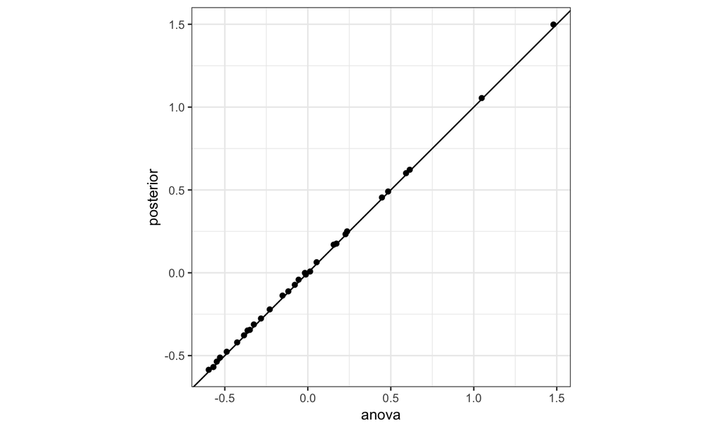

```r
ggplot(data=data.frame(anova=ahat,posterior=fit_SRM$APM),aes(x=anova,y=posterior))+
  geom_point()+geom_abline(slope=1,intercept = 0)+
  coord_fixed()+theme_bw()
```

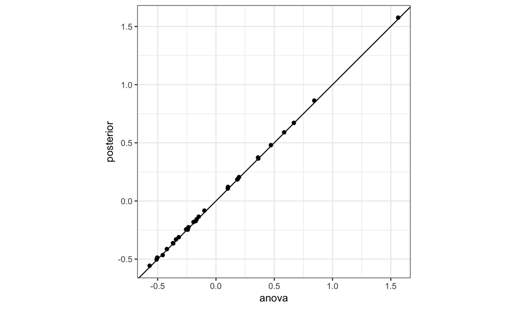

```r
ggplot(data=data.frame(anova=bhat,posterior=fit_SRM$BPM),aes(x=anova,y=posterior))+
  geom_point()+geom_abline(slope=1,intercept = 0)+
  coord_fixed()+theme_bw()
```

```r
fit_SRM$GOF[1:2,] #statistics to check the goodness of fitting
```

```
##     sd.rowmean sd.colmean  dyad.dep   triad.dep
## obs  0.4906692  0.4784861 0.9392867  0.20403144
##      0.5067037  0.4927832 0.9439214 -0.04290418
```

```r
fit_SRM$EZ[1,] #outer(fit_SRM$APM,fit_SRM$BPM,"+")+mean(fit_SRM$BETA)
```

```
##         ARG         AUL         BEL         BNG         BRA         CAN
## -0.07794040  0.20119396  0.47274114 -0.27231126  0.12639108  0.39109046
##         CHN         COL         EGY         FRN         IND         INS
##  0.65814039 -0.21862131 -0.18080266  0.87439754  0.04244846  0.05873294
##         IRN         ITA         JPN         MEX         NTH         PAK
## -0.12913288  0.76432070  1.14712258  0.11145944  0.64902071 -0.20233784
##         PHI         POL         ROK         SAF         SAU         SPN
## -0.02683689 -0.08070833  0.48956943 -0.04639155  0.03904056  0.46910842
##         SWD         TAW         THI         TUR         UKG         USA
##  0.10333439  0.40538545  0.14927293  0.03727601  0.95566614  1.86031544
```

missing dyadic data

Can fill the NAs by MCMC approximation.

Appropriate when missing at random. (many types of link tracing designs, such as egocentric and snowball sampling)

```r
fit_SRM$YPM[1,] #estimate of Y: add epsilon
```

```
##          ARG          AUL          BEL          BNG          BRA
##           NA  0.208100702  0.495727907 -0.239767170  0.121767896
##          CAN          CHN          COL          EGY          FRN
##  0.380297124  0.676787809 -0.168728890 -0.182872326  0.882133875
##          IND          INS          IRN          ITA          JPN
##  0.081284533  0.084503762 -0.178630396  0.773802677  1.142515148
##          MEX          NTH          PAK          PHI          POL
##  0.098379646  0.669411379 -0.175831799 -0.030543475 -0.039650740
##          ROK          SAF          SAU          SPN          SWD
##  0.494026113 -0.026982824  0.001747629  0.488819195  0.083139518
##          TAW          THI          TUR          UKG          USA
##  0.409170751  0.170518602  0.031709477  0.914005344  1.872744222
```

```r
#summary
summary(fit_SRM) #significant non-zero
```

```
##
## Regression coefficients:
##           pmean   psd z-stat p-val
## intercept 0.662 0.184  3.601     0
##
## Variance parameters:
##     pmean   psd
## va  0.281 0.078
## cab 0.236 0.070
## vb  0.272 0.072
## rho 0.858 0.013
## ve  0.239 0.015
```

## Social relations regression model (SRRM)

\[y_{i,j}=\beta_d^Tx_{d,i,j}+\beta_r^Tx_{r,i}+\beta_c^Tx_{c,j}+\mu+a_i+b_j+\epsilon_{i,j}\]

Input: Y- a named matrix Xd - a named array \(n\times n \times p_d\) dyadic covariates Xr - a named matrix \(n\times p_r\) Xc - a named matrix \(n\times p_c\)

```r
#nodal covariates
colnames(IR90s$nodevars)
```

```
## [1] "pop"    "gdp"    "polity"
```

```r
Xn=IR90s$nodevars[topgdp,]
Xn[,1:2]=log(Xn[,1:2]) # use the log

#dyadic covariates
dimnames(IR90s$dyadvars)[[3]]
```

```
## [1] "conflicts"   "exports"     "distance"    "shared_igos" "polity_int"
```

```r
Xd=IR90s$dyadvars[topgdp,topgdp,c(1,3,4,5)]
Xd[,,3]=log(Xd[,,3]) # use log
```

```r
fit_srrm=ame(Y,Xd=Xd,Xr=Xn,Xc=Xn,model = "nrm",plot = FALSE)
```

[output not shown]

[output cut: 802 more lines]

```r
summary(fit_srrm)
```

```
##
## Regression coefficients:
##                   pmean   psd z-stat p-val
## intercept        -6.411 1.258 -5.096 0.000
## pop.row          -0.330 0.132 -2.498 0.012
## gdp.row           0.567 0.151  3.756 0.000
## polity.row       -0.015 0.020 -0.786 0.432
## pop.col          -0.302 0.127 -2.384 0.017
## gdp.col           0.537 0.148  3.635 0.000
## polity.col       -0.006 0.019 -0.309 0.757
## conflicts.dyad    0.076 0.042  1.823 0.068
## distance.dyad    -0.041 0.007 -6.087 0.000
## shared_igos.dyad  0.886 0.187  4.737 0.000
## polity_int.dyad  -0.001 0.001 -1.672 0.095
##
## Variance parameters:
##     pmean   psd
## va  0.265 0.105
## cab 0.214 0.098
## vb  0.251 0.099
## rho 0.785 0.020
## ve  0.157 0.011
```

## do not include the row variance, column variance or dyadic correlation

\[y_{i,j}=\beta_d^Tx_{d,i,j}+\beta_r^Tx_{r,i}+\beta_c^Tx_{c,j}+\mu+\epsilon_{i,j}\]

```r
fit_rm=ame(Y,Xd=Xd,Xr=Xn,Xc=Xn,model = "nrm",rvar = FALSE,cvar = FALSE,dcor=FALSE,plot=FALSE,print = FALSE)
```

```r
summary(fit_rm)
```

```
##
## Regression coefficients:
##                   pmean   psd  z-stat p-val
## intercept        -4.417 0.170 -25.947 0.000
## pop.row          -0.318 0.022 -14.621 0.000
## gdp.row           0.664 0.024  27.417 0.000
## polity.row       -0.007 0.005  -1.335 0.182
## pop.col          -0.280 0.023 -12.328 0.000
## gdp.col           0.622 0.024  25.590 0.000
## polity.col        0.002 0.005   0.509 0.611
## conflicts.dyad    0.238 0.057   4.152 0.000
## distance.dyad    -0.053 0.004 -14.407 0.000
## shared_igos.dyad -0.021 0.028  -0.739 0.460
## polity_int.dyad   0.000 0.001   0.280 0.780
##
## Variance parameters:
##     pmean   psd
## va  0.000 0.000
## cab 0.000 0.000
## vb  0.000 0.000
## rho 0.000 0.000
## ve  0.229 0.011
```

## additive and multiplicative effects model (ame)

\[y_{i,j}=\beta_d^Tx_{d,i,j}+\beta_r^Tx_{r,i}+\beta_c^Tx_{c,j}+\mu+a_i+b_j+u_i^Tv_j+\epsilon_{i,j}\] Input:

Y- a named matrix Xd - a named array \(n\times n \times p_d\) dyadic covariates Xr - a named matrix \(n\times p_r\) Xc - a named matrix \(n\times p_c\) R - dimension of latent factor \(U\) and \(V\) are \(n\times R\) matrices

```r
fit_ame2=ame(Y,Xd=Xd,Xr=Xn,Xc=Xn,model = "nrm",R=2,plot=FALSE,print = FALSE)
```

```r
summary(fit_ame2)
```

```
##
## Regression coefficients:
##                   pmean   psd z-stat p-val
## intercept        -4.096 0.777 -5.270 0.000
## pop.row          -0.281 0.069 -4.081 0.000
## gdp.row           0.567 0.092  6.187 0.000
## polity.row       -0.001 0.010 -0.064 0.949
## pop.col          -0.236 0.072 -3.290 0.001
## gdp.col           0.521 0.100  5.208 0.000
## polity.col        0.008 0.010  0.761 0.447
## conflicts.dyad    0.016 0.037  0.420 0.674
## distance.dyad    -0.038 0.004 -9.542 0.000
## shared_igos.dyad  0.095 0.074  1.281 0.200
## polity_int.dyad  -0.001 0.000 -2.273 0.023
##
## Variance parameters:
##     pmean   psd
## va  0.074 0.023
## cab 0.030 0.017
## vb  0.072 0.022
## rho 0.620 0.037
## ve  0.064 0.004
```